# How We Forget Mass Shootings: An Analysis of Google Trends for Mass Shooting Events

Joe Choo

## Introduction

Gun violence has unfortunately become a horrific normality in American culture. According to the CDC in 2020, 45,222 people died from gun-related injuries in the US (Gramlich 2022). This statistic includes gun murders and gun suicides, along with three other, less common types of gun-related deaths tracked by the CDC: those that were unintentional, those that involved law enforcement and those whose circumstances could not be determined. In this research project, the focus will be on the most publicized and gruesome of the types of gun-related injuries: Mass Shootings. Mass shootings are likely the event people think about when it comes to gun violence with the tragedies of “Columbine (1999), Virginia Tech (2007), Sandy Hook (2012), Orlando (2016), Las Vegas (2017), and Parkland, Florida (2018)” coming to mind as some of the deadliest examples (Jetter and Walker 2018). While these tragedies are largely blamed on radical individuals, still “half of Americans (48%) see gun violence as a big problem in the country today”(Schaeffer 2021). Despite “roughly half of Americans (53%) who favor stricter gun laws,” significant legislation on gun control has not been passed federally (Newall 2021). Many factors have contributed to preventing legislation including a deeply polarized legislative body, a well-established tradition of gun culture in the US, and Americans divided over whether even restricting legal gun ownership would lead to fewer mass shootings (Shufro 2021). However, a not previously-researched hypothesis is the fact that the US news media cycle often moves away from talking about mass shootings months, weeks, sometimes even days after the tragedy. This research project hopes to examine how the media discussion around gun tragedy fades away over time. Outside of understanding mass shootings in the United States, this analysis can help inform human behavior and our propensity to move on with our lives even after such a horrific incident, as well as utilize survival analyses using Google Trends. With this in mind, the accompanying analyses aims to answer or understand 2 core research questions: 1) How long does the discussion of Mass Shootings last 2) What factors or elements of a Mass Shooting incident contribute to how long it is talked about.

## Background and Hypotheses

### Defining “Mass Shootings”

“Mass Shootings” is a difficult topic to research academically due to its varying definitions. “The U.S. government has never defined mass shooting as a separate category of crime, and there is not yet a broadly accepted definition of the term” according to the Gun Policy in America research group (Smart and Schell 2021). While “mass murder” and “mass killing” have been defined by the Federal Bureau of Investigation and Congress respectively, either of these definitions include and exclude incidents that would be considered mass shootings. Additionally, the added complexity of news media in the US not having a consistent definition of “mass shootings” may influence the average US citizen’s perceptions of what is a mass shooting. In this analysis the criteria of a “mass shooting” derives from the Mother Jones’ open-sourced database which took these elements of the incident into its criteria:

1. *the perpetrator took the lives of at least four people*
2. *the killings were carried out by a lone shooter*
3. *shootings occurred in a public place*

While this definition is by no means a perfect one that encapsulates all mass shootings, it is a consistent one that also allows for a robust dataset to be made.

### Hypothesis

Addressing the research questions of 1) How long does the discussion of mass shootings last? and 2) What factors or elements of a mass shooting incident contribute to how long it is talked about? There are couple of hypotheses that come to mind.

The first is that mass shootings that spur on other mass shootings will be talked about more. This phenomena is informed by the “Mass Shootings Contagion Theory” that states that the “through the publicity received from acts of mass murder, perpetrators of this type of criminal act have a fundamental aim of achieving fame or notoriety” thus causing more mass shootings to occur (Johnston and Joy 2016). The hypothesis is that a mass shooting incident unintentionally inspires another mass shooting to occur, which elongates the original mass shooting’s coverage or interest in US media.

The next hypothesis revolves around race of the shooter. It seems that white perpetrators are often talked more about or are given the benefit of the doubt by using terms like “estranged” or “troubled” rather than “terrorist” or “killer” like non-white perpetrators. This fundamental difference in perception of a mass shooter may in fact humanize the shooter which may bring more attention to the incident rather than being forgotten about more easily and brushed away as a “terrorist” or even a “thug.”

On the contrary, the other hypothesis is that non-white perpetrators are highlighted much more than white shooters because they can be sensationalized by their race. Using terminology such as “terrorist” or “illegal” can potentially contribute to people reacting much more viscerally to the shooting and thus prolong the eventual media cycle takeover of the next news story.

Lastly, the last hypothesis revolves around violence of the event. Simply, this hypothesis states that one of the most influential factors when it comes to the duration of a shooting’s interest in the public eye is how deadly or violent the event was. From personal experience, it seemed that Orlando and Las Vegas shooting saw so much more and sustained media attention due to their record-breaking nature in terms of deaths and injuries.

## Research Design

The questions remain rather broad so both a flexible and consistent methodology was needed to both explore the duration of public interest and accompanying factors that might prolong/decrease the attention span of the public. The “public” in this case will be people who use Google and data will be sourced from the Mother Jones Database mentioned above as well as Google Trend data.

### Mother Jones Database

The Mother Jones Database is a open-source database that documents mass shootings in the United States. It originated after the 2012 Aurora, Colorado, movie theater shooting, with the self-proclaimed focus on “indiscriminate rampages in public places resulting in four or more victims killed by the attacker, [excluding] shootings stemming from more conventionally motivated crimes such as armed robbery or gang violence (or in which the perpetrators have not been identified).” The database extends back to the 1982 welding shop shooting in Miami, Florida, and is updated to the most recent Sacramento County church shooting from February 2022. The database also includes variables: date, location, summary, number of fatalities, number of injuries, number of total victims (fatalities + injuries), location type (ie Religious, Workplace), age of the shooter, prior signs of mental illness, whether or not the weapon was obtained illegally, where the weapon was obtained, type of weapon, detailed specifications of the weapon, race, gender, sources relevant to the data entry, latitude, and longitude. In total, there are 126 events in the database but the analysis will only focus on the 75 most recent, with the 2010 Hartford Beer Distributor shooting in Manchester, Connecticut, being the oldest.

It is worthwhile to also point out that Mother Jones is a politically left-leaning news organization. While the database claims to be open-source, well-maintained, and appears to be reliable due to cited references in the “sources” column, bias can still play a role in deciding what factors to include for example.

### Google Trend

Google Trends is a tool from Google that can compare volume and popularity of search queries on Google over a specified period of time. Measuring public attention is an abstract task but the use of a popular search engine like Google is an appropriate way to represent the interests of the general US population. Especially when it comes to mass shootings, people may use Google to keep up with recent news and updates on victims or information about the perpetrator, thus being a good source when it comes to aggregating “public attention” data. Additionally, Google Trends has the added benefit of comparing interest of search queries in relation with itself, which is useful for a survival analysis.

The methodology of obtaining data using Google Trends was not automated thus vulnerable to human error. However, because a systematized way of collecting data was implemented over 75 events, hopefully the variation caused by human judgment evens itself out.

The process for finding the “Days Trending” of an event is as follows:

1. The Search Query for the event was either “Event Name as appeared on the Mother Jones Database” or “Location + Shooting”. While variations between the two were not all that different, it was still important to include both types of searches as one might be more commonly referred to when talking about the event (ie Marjory Stoneman Douglas High School shooting vs Parkland shooting). The one with the most days trending was used.
2. The time period chosen ranged from 2 days prior to the event to 1 month after the event. So for example, the  
   “Oxford High School shooting” occurred on 11/30/2021 so the date range used was 11/28/2021-12/30/2021. This range was used so that a baseline could be established by Google Trends of what a “not-trending” rating would be and extends out to when typically a trend will die out by. A longer period of time could be chosen but then the unit of time would be weeks or months as opposed to days, and for the sake of our analysis, more granular time units is more appropriate and informative.
3. The measured time of days trending spanned from the peak of the trend (popularity value 100) to the day where the volume of searches returned back to the original pre-peak level (usually a value of 1 or “<1”). This measurement was used to define the “Days Trending” variable because of its consistency across all the different events as well as mimicking what might a “trend” or “public perception” of an event might look like on Google. There is peak interest (usually the day of or day after the day of the event) and as the days progress, there is generally a consistent decrease in interests. Some spikes might occur after the initial peak due to revelation of new information or coverage but in general, the popularity of the search queries is monotonically decreasing.

### Survival Analysis

Survival analysis is a statistical procedure where the goal is to measure the expected duration of time until one event occurs. This is most often used in biology or mechanical systems to measure the time until death of an organism or the time until a mechanical part breaks respectively. In this analysis, survival analysis will be used to measure the expected duration of time (in days) until a mass shooting event falls out of public attention through Google Trends. Survival analysis takes in inputs such as the time it takes for the event to occur, censorship, as well as additional predictors. Censorship is used to denote whether the event was observed, in this analysis, every “Days Trending” event had an observed end date so this variable would always be observed. The output of a survival analysis is a chart much like Google Trends in terms of visualization. On the x-axis is the unit of time and on the y-axis is the probability of surviving (trend not dying) or the proportion of shootings that are expected to be talked about in Google at a given point in time. Because the y-axis is the probability of survival, the graph is monotonically decreasing since the probability of the trend “reviving” is not going to happen in our analysis.

There are several different models to consider when conducting survival analyses. There are two that this analyses will utilize. The first is the Kaplan-Meier Curve Model and the second is the Cox Proportional Hazards Models. The Kaplan-Meier Curve is the simplest and most straight forward model but also lends itself to the most information and interpretation. The model has very few assumptions and is a purely descriptive method that can help answer the first question of the research project. However, because of its simplicity, it does not take in many inputs which is why the a second model was utilized. The Cox Proportional Hazards Model is more complex and can take in multiple inputs. This is important to analyze how other factors such as the race of the shooter or the fatality of the shooting may be correlated with how long the trend lasts. These models are much more robust and provide more statistical insights than say a Logistic Regression or Linear Model. Additionally, because there are some outliers in the data, Logistic Regression or Linear Regression may be skewed, which is why the survival analysis is more advantageous to use (because of its flexibility with extreme values).

## Analysis and Results

### EDA

Prior to the Survival Analysis, some Exploratory Data Analysis is included to paint a better picture of the dataset.

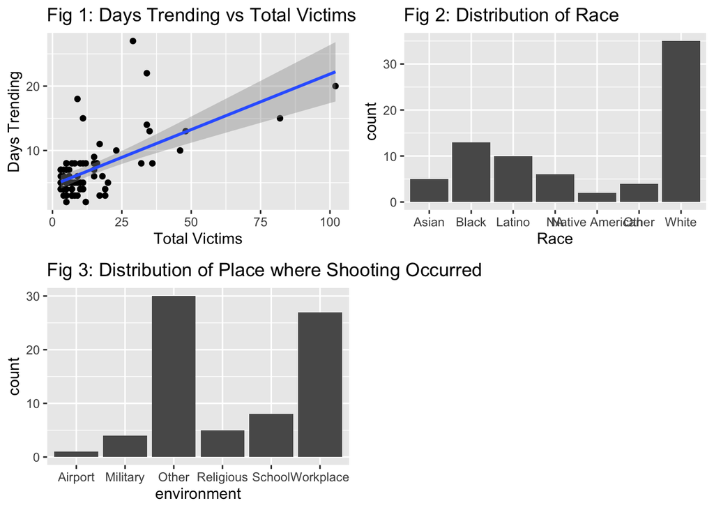

[output not shown]

At a high level, from (Fig 1), it appears that there is a positive trend between days that a shooting trends on Google and the total number of victims. This intuitively makes sense as more violent shootings garner more of the public attention. (Fig 2) shows that approximately half of shootings were committed by a White perpetrator. (Fig 3) shows that “Other” and “Workplace” were the most common sites for a shooting to occur. Schools also appear to be a surprisingly frequent place for mass shootings to occur.

#### Survival Analysis General

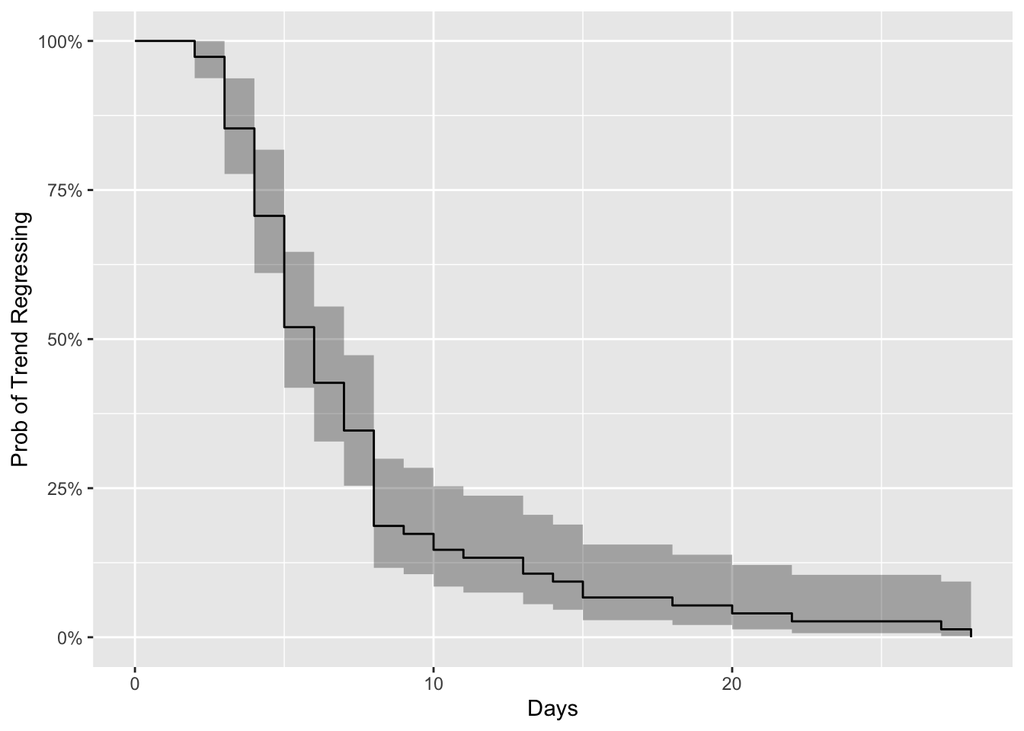

From this first survival analysis curve, we see that within the first week (7 days), more than half of mass shooting events leave the public’s attention. This can also be interpreted as that public attention or trend of a mass shooting will be expected to die out in a week about half of the time. The slope of the curve is also telling, it seems that in the first few days, the drop-off of the expected probability of the trend dying out is relatively slow compared to around days 4-7. This means that on Days 4-7, there is a larger volatility and is where many of the observed trends end. Around 10% of shootings are expected to be talked about more than 2 weeks after the peak of the interest on the shooting event.

#### Survival Analysis: Race

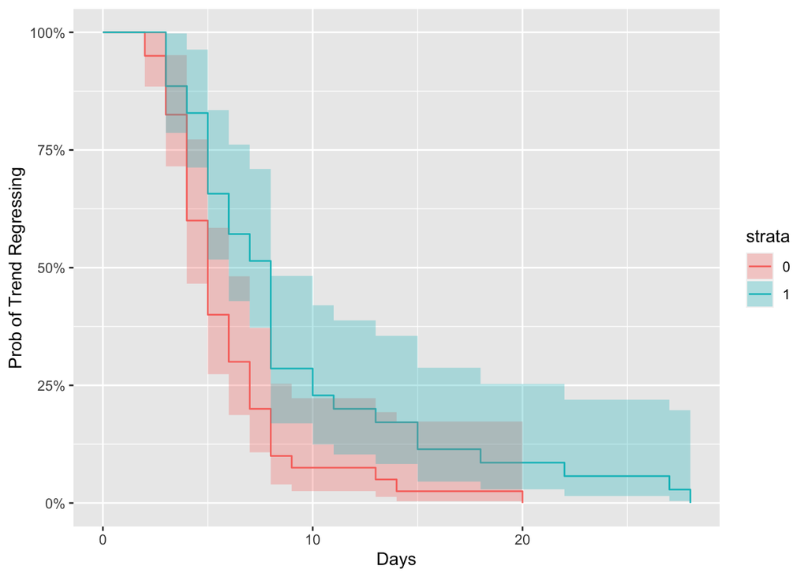

To see the effects of race on a shooting’s probability to prolong a trend, a strata was created based on race (1 = White, 0 = Non-White). It appears that while on average, White shooters last longer in public perception, there is no significant difference in the probability of trend regressing as the confidence intervals overlap.

#### Survival Analysis: Shooting Occuring with 1 Month

To address the other hypothesis of the contagion effect of mass shootings, a strata based on another shooting occuring within 30 days was added (1 = another mass shooting occurred 30 days after a given shooting event, 0 = otherwise).

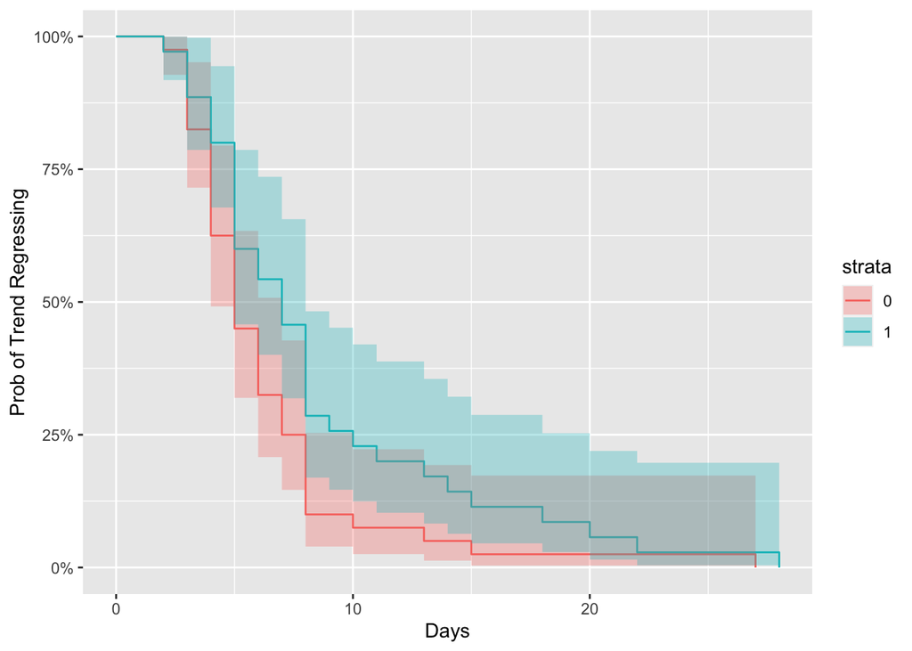

There appears to be a slight increase on average of the probability of trend regressing over all days. However, similar to the previous survival curve, there does not appear to be a significant relationship between whether another shooting occurred or not and prolonging the days of public attention.

#### Table of Cox Proportional Hazards Model

|  | coef | exp(coef) | se(coef) | z | Pr(>\|z\|) |
| --- | --- | --- | --- | --- | --- |
| Shooting_in_Month | -0.281 | 0.755 | 0.296 | -0.951 | 0.342 |
| fatalities | -0.069 | 0.934 | 0.031 | -2.198 | 0.028 |
| injured | -0.026 | 0.974 | 0.015 | -1.682 | 0.093 |
| environmentMilitary | -0.991 | 0.371 | 1.150 | -0.861 | 0.389 |
| environmentOther | -0.771 | 0.462 | 1.147 | -0.672 | 0.501 |
| environmentReligious | -1.142 | 0.319 | 1.186 | -0.963 | 0.336 |
| environmentSchool | -2.106 | 0.122 | 1.202 | -1.752 | 0.080 |
| environmentWorkplace | -1.159 | 0.314 | 1.116 | -1.038 | 0.299 |
| age_of_shooter | 0.002 | 1.002 | 0.012 | 0.148 | 0.883 |
| RaceBlack | -0.770 | 0.463 | 0.561 | -1.372 | 0.170 |
| RaceLatino | -0.579 | 0.560 | 0.626 | -0.926 | 0.354 |
| RaceNA | -0.923 | 0.397 | 0.737 | -1.252 | 0.211 |
| RaceNative American | -0.392 | 0.676 | 0.861 | -0.455 | 0.649 |
| RaceOther | -0.356 | 0.700 | 0.790 | -0.451 | 0.652 |
| RaceWhite | -1.119 | 0.327 | 0.551 | -2.031 | 0.042 |

In order to dive deeper into what factors might be significantly related to prolonging/shortening the public’s attention of a shooting after its peak interest, a Cox Proportional Hazards model was used with these additional predictors: “Another Shooting in Month”, “Number of Fatalities”, “Number of injuries” “Type of environment”, “Age of Shooter”, “Race of Shooter.” Other factors such as mental health or type of weapon were not used because of incompleteness or lack of confidence in that quality of data.

It appears that fatalities and the shooter being White are significantly associated with probability of days trending as well as the injury and whether the shooting occurred at a school and the probability of days trending (p-value <.1). An alpha of .1 was used in this analysis to aid with discussion and deliver meaningful insights that otherwise might be restricted with a lower alpha value.

To interpret the coefficients, a negative coefficient indicates that there is a “protective effect” of the variable with which it is associated, or that the expected probability of the number of days that a mass shooting event will remain in public attention is prolonged.

With that in mind, for every additional person who dies in a mass shooting event, the probability of the trend coming to an end is reduced by 6.9%, holding all else constant.

For every additional person who is injured in a mass shooting event, the probability of the trend coming to an end is reduced by 2.6%, holding all else constant.

## Discussion

To reference the original questions of interest: 1) How long does the discussion of Mass Shootings last 2) What factors or elements of a Mass Shooting incident contribute to how long it is talked about, the first question can be answered quite directly. It appears that approximately half of mass shootings are discussed or trend on Google by the end of the 1st week after it has reached its peak. The second element is a bit more nuanced but according to our Cox Proportional Hazards Model, it appears that the number of deaths, injuries, whether or not the shooting took place at a school, and a White shooter, were the significant predictors of extending public attention. The result of this analysis confirms the second and fourth hypotheses laid out in the Hypothesis section of this research paper. The explanation or mechanisms may not be accurate, but statistically speaking, it seems that White perpetrators and more violent types of mass shootings are significantly associated with how long public attention lasts.

Interestingly, the Mass Shooting Contagion Theory and the third hypothesis revolving around a “minority threat” do not seem to hold. In the first hypothesis, perhaps that a mass shooting may be linked to causing a successive shooting to occur, but the media and public attention shifts to the next shooting rather than reminiscing on the first. This explanation may make sense and is in line with the idea that the news cycle always searches for the next story, which informs the public’s attention to the next shooting. The fact that White shooters were significantly associated with prolonging the lifespan of pubic attention on a mass shooting lends itself to disproving the counter-hypothesis that non-white perpetrators are somehow seen as more dangerous and therefore are talked about more.

What is interesting to point out is that school shootings had such a high association with prolonging the probability of a trend dying. In reference to the EDA, school shootings were trending for an average of 11.8 days while the next highest average trending event occurred in religious locations. On a practical level, this finding should not be all that surprising as the intersection between innocence in students and the violence of a mass shooting is so tragic. Anecdotally, some of the most remember shootings of the modern era include Sandy Hook Elementary and the Parkland shootings, which is in line with the results of the analysis.

## Conclusion, Limitations, and Suggestions for the Future

To conclude the analysis, it appears that people’s interests are quite ephemeral even if it comes to an event as violent as a mass shooting. No shootings trended more than 28 days (Las Vegas shooting) and more than half of shootings were not talked about at a significant volume past 1 week of a shooting’s peak interest. Some factors, namely the violent/shocking nature of the shooting (at a school and with more injuries or deaths) as well as the race of the shooter being white appeared to significantly prolong days that a shooting will stop being talked about by the public at large.

While these findings were interesting and informative, it is also important for limitations should be pointed out. Firstly, as alluded to earlier, the bulk of this analysis relies on human judgment in terms of the Days Trending calculations. Additionally, with the Days Trending calculation, the inherent use of Google Trends lends itself to criticism. Google Trends is an aggregator of data and does not aim to precisely reflect the actual volume or popularity of a given trend. Perhaps a shooting appeared to not be talked about in a couple of days just because the gap between the peak volume and the trough was so large. So even if a Google search query was “trending”, the graph on Google Trends may not reflect this status due to it not being comparable to the height of its peak (popularity rating of 100). Additionally, no causative statements can be made with this analysis. Like regression, survival analysis can only do its best describing significant correlation between a predictor and response variable. Any implication that a factor of a mass shooting “causes” it to be talked about more/less is not accurate. Of course this limitation can not be accounted for that much due to the nature of this study and inability to have proper experimental conditions.

As for the future, the next step would be to include more variables about the perpetrator such as the type of weapon used and if the weapon was obtained legally. These factors were not considered because too many inconsistencies were seen in the data as well as obscurity as to whether or not the information is correct. To extend on this, it would be interesting to see how mental health of a shooter might relate to the public discourse around a shooting, but this information is often sensitive, hearsay, or unavailable. Also, looking at regional level data will be interesting to answer a question such as “How long does talks about a shooting last on the local level compared to the national level” or simply “How quickly does the national attention fade compared to the local attention.” Personally in Las Vegas, it seemed that my entire senior year of high school was filled with updates, blood drives, donation causes, or campaigns addressing the Las Vegas shooting. It would be interesting to see if this is the same case in other cities and see how long the duration of local discussion and interest lasts.

Overall, this analysis helped support some of the notion that prolonged public interests in shooting is lacking and that it might attribute to the normalcy of gun violence in America. Conducting this research was informative to my understanding of gun violence, mass shootings, and public attention through Google Trends. I believe that there is great opportunity to extend on this research and adds another statistical element to such an important issue that more than half of Americans agree upon needs to change.

## Bibliography

Berk, R. (n.d.) What is a Mass Shooting? What Can Be Done?. Dept of Criminology of University of Pennsylvania. https://crim.sas.upenn.edu/fact-check/what-mass-shooting-what-can-be-done.

Follman, M. Aronsen, G., & Pan, D. (2022). A Guide to Mass Shootings in America. Mother Jones. https://www.motherjones.com/politics/2012/07/mass-shootings-map/.

Gramlich, J. (2022). What the Data Says about gun deaths in the US. Pew Research Center. https://www.pewresearch.org/fact-tank/2022/02/03/what-the-data-says-about-gun-deaths-in-the-u-s/.

Gray, S. (2019). Here’s a Timeline of the Major Gun Control Laws in America. Time Magazine. https://time.com/5169210/us-gun-control-laws-history-timeline/.

Jetter, M., & Walker, J. (2018). The effect of media coverage on mass shootings. IZA Institue of Labor Economics. Available at SSRN 3286159: https://ftp.iza.org/dp11900.pdf.

Jilani, Z., (2019). How the Media Can Help Prevent Mass Shootings. Greater Good Science Center of Berkeley. https://greatergood.berkeley.edu/article/item/how_the_media_can_help_prevent_mass_shootings.

Johnston, J., & Joy, A. (2016). Mass shootings and the media contagion effect. Western New Mexico University. https://www.apa.org/news/press/releases/2016/08/media-contagion-effect.pdf.

Lee, K. J. (2018). Mass shootings and media contagion theory: Social media’s influence on frequency of incidents. Elon Journal of Undergraduate Research in Communications, 9(2), 27-35.

Lopez, B.E., Crimmins, D., & Haskins, P. (2020). Advancing Mass Shooting Research To Inform Practice. National Institute of Justice Journal. https://nij.ojp.gov/topics/articles/advancing-mass-shooting-research-inform-practice.

Newall, M. (2021). Americans favor stricter gun laws, though support has declined from 2019. Ipsos. https://www.ipsos.com/en-us/americans-favor-stricter-gun-laws-though-support-has-declined-from-2019.

Schaeffer, K. (2021). Key facts about Americans and guns. Pew Research Center. https://www.pewresearch.org/fact-tank/2021/09/13/key-facts-about-americans-and-guns/.

Shufro, C. (2021). A Brief History of Guns in the US. Hopkins Bloomberg Public Health. https://magazine.jhsph.edu/2021/brief-history-guns-us.

Smart, R., & Schell, T. (2021). Mass Shootings in the United States. Gun Policy in America. https://www.rand.org/research/gun-policy/analysis/essays/mass-shootings.html.